# Praktikum 4-ARMA

## White Noise

Pembangkitan data berpola AR, MA, ARMA, dan banyak proses deret waktu lainnya diawali pembangkitan *white noise*. *White noise* merupakan sederet nilai dari peubah bebas stokastik identik. Oleh karena itu, *white noise* memiliki dua karakteristik penting:

1. *White noise* tidak memiliki autokorelasi (**karena saling bebas**)
2. Nilai harapan dan ragam *white noise* sama (**karena berasal dari peubah acak bebas stokastik identik**)

*White noise* dibangkitkan dari suatu peubah acak, umumnya peubah acak normal.

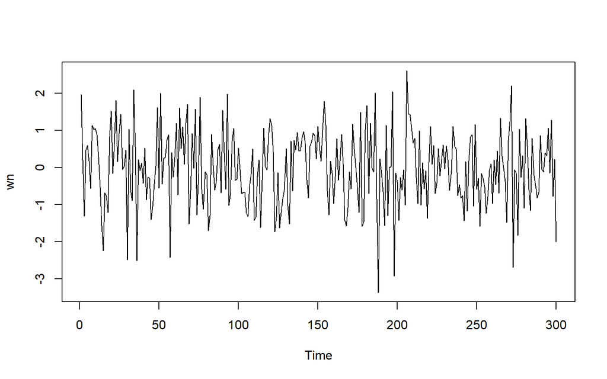

```r
set.seed(1105)
wn <- rnorm(300)
ts.plot(wn)
```

Dapat terlihat bahwa *white noise* tidak memiliki autokorelasi dari ACF. Perhatikan bahwa lag ke-0 adalah korelasi observasi ke-t dengan dirinya sendiri. Nilai korelasi tersebut pasti 1. Sebagai alternatif, lag pertama di plot ACF dapat ditetapkan sebagai 1 (alih-alih 0) dengan menambahkan argumen `xlim(1, lag akhir)`. Plot tersebut dapat disandingkan bersamaan dengan membuat matriks $1 \times 2$ dengan `par(mfrow = c(1,2))`.

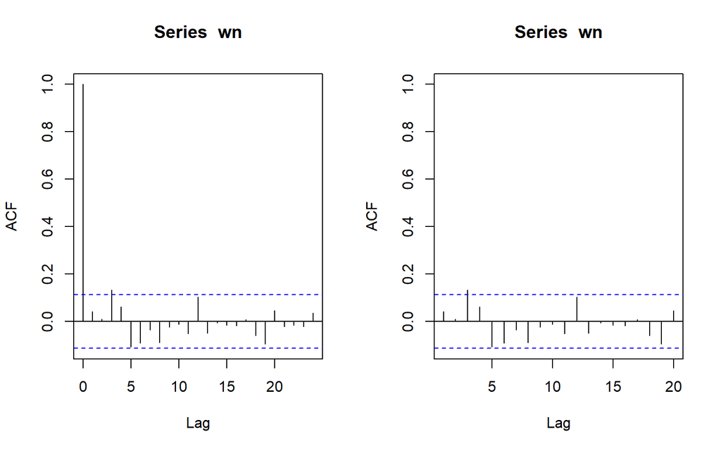

```r
par(mfrow = c(1, 2))
acf(wn)
acf(wn, xlim = c(1, 20))
```

## Proses MA

Proses MA dapat dituliskan sebagai berikut:

$$y_{t} = c + e_t + \theta_{1}e_{t-1} + \theta_{2}e_{t-2} + \dots +
\theta_{q}e_{t-q} = c+{e_t+\sum_{i=1}^p \theta_ie_{t-i}}$$
Terlihat bahwa $e_t$, atau *white noise*, berperan penting dalam pembangkitan proses MA.

Akan dicoba membangkitkan proses MA paling sederhana, yaitu MA(2) dengan $\theta = 0.4$ dan $\theta = 0.6$ sebanyak 300 observasi dan $c=0$. Karena diperlukan satu nilai awal untuk $e_{t-1}$ dan $e_{t-2}$ , masukkan nilai pertama white noise sebagai nilai awal tersebut.

```r
set.seed(1105)
ma <- wn[c(1,2)]
```

Nilai-nilai selanjutnya dapat dicari melalui *loop*. Bentuk loop dapat dilihat dari rumus MA(2) yang hendak dibangkitkan:

$$y_t = e_t+0.4e_{t-1}+0.6e_{t-2}$$

```r
set.seed(1105)
for(i in 3:300){
   ma[i] <- wn[i] + 0.4 * wn[i - 1]+ 0.6 * wn[i - 2]
}
ma
```

```
##   [1]  1.964844994  0.197326757 -0.045866232  0.064520731 -0.001406993
##   [6]  0.682676949 -0.142139941  1.004936004  1.130795176  2.139208263
##  [11]  1.912884741  1.268268368  0.104881385 -1.608417522 -3.188737831
##  [16] -2.515636465 -2.396114194 -1.935062787 -0.129390388  1.120186236
##  [21]  0.944108341  1.471986381  1.956183205  1.257064604  2.058942674
##  [26]  1.891937490  1.060311634  0.866850311  0.440642313 -2.285154405
##  [31]  0.309154661 -1.681399346 -0.518328820  1.371425182  0.861370377
##  [36] -1.030727100 -0.450482171 -1.504514463  0.207887155 -0.431677718
##  [41]  0.416202623 -0.922776974 -0.310044633 -0.919270155 -1.679290960
##  [46] -1.789285724 -1.709355892 -0.773415377  1.366250179  0.112734276
##  [51]  2.741691703  0.020469398  1.259032247  0.099840683  0.985697057
##  [56]  1.330866411 -1.634281552 -0.047517360 -1.552275978  0.412846722
##  [61]  1.148990723 -0.086486271  2.028568221  0.715727317  2.264462644
##  [66]  0.825315202  1.886262369  2.220484589 -0.124496782 -0.212922999
##  [71] -0.245338483 -0.032948854  2.111039756 -0.665734312  0.245557744
```

[output cut: 45 more lines]

Selain menggunakan cara di atas, pembangkitan proses MA(2) dapat dilakukan dengan fungsi `arima.sim()` sebagai berikut.

```r
set.seed(1105)
ma2 <- arima.sim(list(order=c(0,0,2), ma=c(0.4,0.6)), n=300)
ma2
```

```
## Time Series:
## Start = 1
## End = 300
## Frequency = 1
##   [1] -0.045866232  0.064520731 -0.001406993  0.682676949 -0.142139941
##   [6]  1.004936004  1.130795176  2.139208263  1.912884741  1.268268368
##  [11]  0.104881385 -1.608417522 -3.188737831 -2.515636465 -2.396114194
##  [16] -1.935062787 -0.129390388  1.120186236  0.944108341  1.471986381
##  [21]  1.956183205  1.257064604  2.058942674  1.891937490  1.060311634
##  [26]  0.866850311  0.440642313 -2.285154405  0.309154661 -1.681399346
##  [31] -0.518328820  1.371425182  0.861370377 -1.030727100 -0.450482171
##  [36] -1.504514463  0.207887155 -0.431677718  0.416202623 -0.922776974
##  [41] -0.310044633 -0.919270155 -1.679290960 -1.789285724 -1.709355892
##  [46] -0.773415377  1.366250179  0.112734276  2.741691703  0.020469398
##  [51]  1.259032247  0.099840683  0.985697057  1.330866411 -1.634281552
```

[output cut: 49 more lines]

## Karakteristik MA(2)

### Plot Time Series

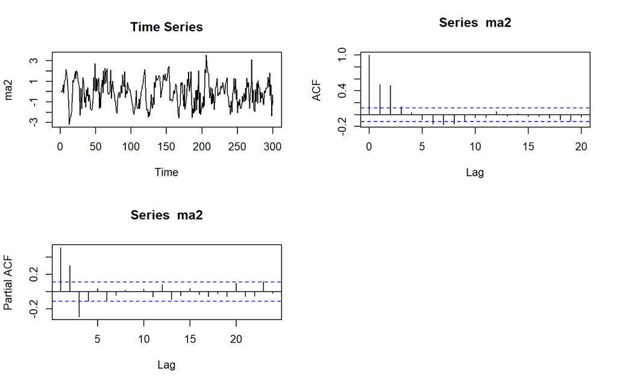

```r
par(mfrow = c(2, 2))

# Plot Time Series
ts.plot(ma2)
title("Time Series")

# Plot ACF
acf(ma2, lag.max = 20)

# Plot PACF
pacf(ma2)
```

1. Berdasarkan plot time series, terlihat bahwa data MA(2) yang dibangkitkan stasioner dalam rataan
2. Berdasarkan plot AFC tersebut, terlihat bahwa plot ACF *cuts off* di lag ketiga
3. Berdasarkan plot PACF tersebut, terlihat bahwa plot PACF cenderung *tails off* dan membentuk gelombang sinus

### Plot EACF

```r
TSA::eacf(ma)
```

```
## AR/MA
##   0 1 2 3 4 5 6 7 8 9 10 11 12 13
## 0 x x x o o x x x o o o  o  o  o
## 1 x x o o o o o o o o o  o  o  o
## 2 x x o x o o o o o o o  o  o  o
## 3 x x x x o o o o o o o  o  o  o
## 4 x x x o x o o o o o o  o  o  o
## 5 x x x x o o o o o o o  o  o  o
## 6 x x o x o o o o o o o  o  o  o
## 7 x x o o o o o o o o o  o  o  o
```

### Scatterplot Antar Lag

#### Korelasi antara $Y_t$ dengan $Y_{t-1}$

```r
#Yt
yt_ma <- ma[-1]
yt_ma
```

```
##   [1]  0.197326757 -0.045866232  0.064520731 -0.001406993  0.682676949
##   [6] -0.142139941  1.004936004  1.130795176  2.139208263  1.912884741
##  [11]  1.268268368  0.104881385 -1.608417522 -3.188737831 -2.515636465
##  [16] -2.396114194 -1.935062787 -0.129390388  1.120186236  0.944108341
##  [21]  1.471986381  1.956183205  1.257064604  2.058942674  1.891937490
##  [26]  1.060311634  0.866850311  0.440642313 -2.285154405  0.309154661
##  [31] -1.681399346 -0.518328820  1.371425182  0.861370377 -1.030727100
##  [36] -0.450482171 -1.504514463  0.207887155 -0.431677718  0.416202623
##  [41] -0.922776974 -0.310044633 -0.919270155 -1.679290960 -1.789285724
##  [46] -1.709355892 -0.773415377  1.366250179  0.112734276  2.741691703
##  [51]  0.020469398  1.259032247  0.099840683  0.985697057  1.330866411
##  [56] -1.634281552 -0.047517360 -1.552275978  0.412846722  1.148990723
##  [61] -0.086486271  2.028568221  0.715727317  2.264462644  0.825315202
##  [66]  1.886262369  2.220484589 -0.124496782 -0.212922999 -0.245338483
##  [71] -0.032948854  2.111039756 -0.665734312  0.245557744  1.043130336
```

[output cut: 45 more lines]

```r
#Yt-1
yt_1_ma <- ma[-300]
yt_1_ma
```

```
##   [1]  1.964844994  0.197326757 -0.045866232  0.064520731 -0.001406993
##   [6]  0.682676949 -0.142139941  1.004936004  1.130795176  2.139208263
##  [11]  1.912884741  1.268268368  0.104881385 -1.608417522 -3.188737831
##  [16] -2.515636465 -2.396114194 -1.935062787 -0.129390388  1.120186236
##  [21]  0.944108341  1.471986381  1.956183205  1.257064604  2.058942674
##  [26]  1.891937490  1.060311634  0.866850311  0.440642313 -2.285154405
##  [31]  0.309154661 -1.681399346 -0.518328820  1.371425182  0.861370377
##  [36] -1.030727100 -0.450482171 -1.504514463  0.207887155 -0.431677718
##  [41]  0.416202623 -0.922776974 -0.310044633 -0.919270155 -1.679290960
##  [46] -1.789285724 -1.709355892 -0.773415377  1.366250179  0.112734276
##  [51]  2.741691703  0.020469398  1.259032247  0.099840683  0.985697057
##  [56]  1.330866411 -1.634281552 -0.047517360 -1.552275978  0.412846722
##  [61]  1.148990723 -0.086486271  2.028568221  0.715727317  2.264462644
##  [66]  0.825315202  1.886262369  2.220484589 -0.124496782 -0.212922999
##  [71] -0.245338483 -0.032948854  2.111039756 -0.665734312  0.245557744
```

[output cut: 45 more lines]

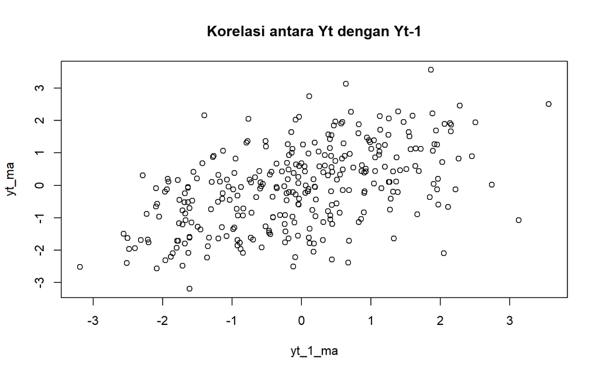

```r
plot(y=yt_ma,x=yt_1_ma, main="Korelasi antara Yt dengan Yt-1")
```

Berdasarkan scatterplot tersebut, terlihat bahwa terdapat hubungan positif antara $Y_t$ dengan $Y_{t-1}$. Hal ini sesuai dengan teori yang ada

```r
cor_1 <- cor(yt_ma,yt_1_ma)
```

Korelasi antara $Y_t$ dengan $Y_{t-1}$ dari hasil simulasi mendekati perhitungan teoritis yaitu 0.5137526

#### Korelasi antara $Y_t$ dengan $Y_{t-2}$

```r
#Yt
yt_ma2 <- ma[-c(1,2)]
yt_ma2
```

```
##   [1] -0.045866232  0.064520731 -0.001406993  0.682676949 -0.142139941
##   [6]  1.004936004  1.130795176  2.139208263  1.912884741  1.268268368
##  [11]  0.104881385 -1.608417522 -3.188737831 -2.515636465 -2.396114194
##  [16] -1.935062787 -0.129390388  1.120186236  0.944108341  1.471986381
##  [21]  1.956183205  1.257064604  2.058942674  1.891937490  1.060311634
##  [26]  0.866850311  0.440642313 -2.285154405  0.309154661 -1.681399346
##  [31] -0.518328820  1.371425182  0.861370377 -1.030727100 -0.450482171
##  [36] -1.504514463  0.207887155 -0.431677718  0.416202623 -0.922776974
##  [41] -0.310044633 -0.919270155 -1.679290960 -1.789285724 -1.709355892
##  [46] -0.773415377  1.366250179  0.112734276  2.741691703  0.020469398
##  [51]  1.259032247  0.099840683  0.985697057  1.330866411 -1.634281552
##  [56] -0.047517360 -1.552275978  0.412846722  1.148990723 -0.086486271
##  [61]  2.028568221  0.715727317  2.264462644  0.825315202  1.886262369
##  [66]  2.220484589 -0.124496782 -0.212922999 -0.245338483 -0.032948854
##  [71]  2.111039756 -0.665734312  0.245557744  1.043130336  0.059237676
```

[output cut: 45 more lines]

```r
#Yt-2
yt_2_ma <- ma[-c(299,300)]
yt_2_ma
```

```
##   [1]  1.964844994  0.197326757 -0.045866232  0.064520731 -0.001406993
##   [6]  0.682676949 -0.142139941  1.004936004  1.130795176  2.139208263
##  [11]  1.912884741  1.268268368  0.104881385 -1.608417522 -3.188737831
##  [16] -2.515636465 -2.396114194 -1.935062787 -0.129390388  1.120186236
##  [21]  0.944108341  1.471986381  1.956183205  1.257064604  2.058942674
##  [26]  1.891937490  1.060311634  0.866850311  0.440642313 -2.285154405
##  [31]  0.309154661 -1.681399346 -0.518328820  1.371425182  0.861370377
##  [36] -1.030727100 -0.450482171 -1.504514463  0.207887155 -0.431677718
##  [41]  0.416202623 -0.922776974 -0.310044633 -0.919270155 -1.679290960
##  [46] -1.789285724 -1.709355892 -0.773415377  1.366250179  0.112734276
##  [51]  2.741691703  0.020469398  1.259032247  0.099840683  0.985697057
##  [56]  1.330866411 -1.634281552 -0.047517360 -1.552275978  0.412846722
##  [61]  1.148990723 -0.086486271  2.028568221  0.715727317  2.264462644
##  [66]  0.825315202  1.886262369  2.220484589 -0.124496782 -0.212922999
##  [71] -0.245338483 -0.032948854  2.111039756 -0.665734312  0.245557744
```

[output cut: 45 more lines]

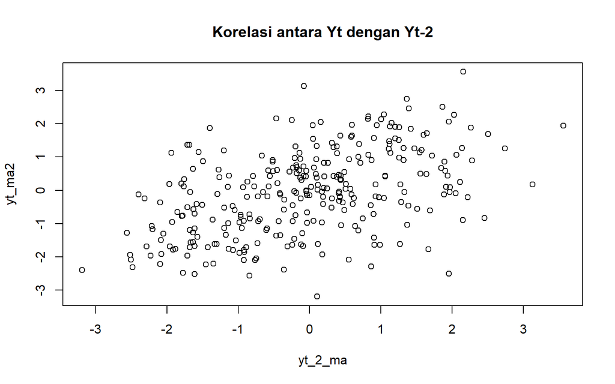

```r
plot(y=yt_ma2,x=yt_2_ma,main="Korelasi antara Yt dengan Yt-2")
```

```r
cor_2<-cor(yt_ma2,yt_2_ma)
```

Korelasi antara $Y_t$ dengan $Y_{t-2}$ hasil simulasi mendekati teori yang ada yaitu 0.4848173

#### Korelasi antara $Y_t$ dengan $Y_{t-3}$

```r
#Yt
yt_ma3 <- ma[-c(1,2,3)]
yt_ma3
```

```
##   [1]  0.064520731 -0.001406993  0.682676949 -0.142139941  1.004936004
##   [6]  1.130795176  2.139208263  1.912884741  1.268268368  0.104881385
##  [11] -1.608417522 -3.188737831 -2.515636465 -2.396114194 -1.935062787
##  [16] -0.129390388  1.120186236  0.944108341  1.471986381  1.956183205
##  [21]  1.257064604  2.058942674  1.891937490  1.060311634  0.866850311
##  [26]  0.440642313 -2.285154405  0.309154661 -1.681399346 -0.518328820
##  [31]  1.371425182  0.861370377 -1.030727100 -0.450482171 -1.504514463
##  [36]  0.207887155 -0.431677718  0.416202623 -0.922776974 -0.310044633
##  [41] -0.919270155 -1.679290960 -1.789285724 -1.709355892 -0.773415377
##  [46]  1.366250179  0.112734276  2.741691703  0.020469398  1.259032247
##  [51]  0.099840683  0.985697057  1.330866411 -1.634281552 -0.047517360
##  [56] -1.552275978  0.412846722  1.148990723 -0.086486271  2.028568221
##  [61]  0.715727317  2.264462644  0.825315202  1.886262369  2.220484589
##  [66] -0.124496782 -0.212922999 -0.245338483 -0.032948854  2.111039756
##  [71] -0.665734312  0.245557744  1.043130336  0.059237676 -0.234622509
```

[output cut: 45 more lines]

```r
#Yt-3
yt_3_ma <- ma[-c(298,299,300)]
yt_3_ma
```

```
##   [1]  1.964844994  0.197326757 -0.045866232  0.064520731 -0.001406993
##   [6]  0.682676949 -0.142139941  1.004936004  1.130795176  2.139208263
##  [11]  1.912884741  1.268268368  0.104881385 -1.608417522 -3.188737831
##  [16] -2.515636465 -2.396114194 -1.935062787 -0.129390388  1.120186236
##  [21]  0.944108341  1.471986381  1.956183205  1.257064604  2.058942674
##  [26]  1.891937490  1.060311634  0.866850311  0.440642313 -2.285154405
##  [31]  0.309154661 -1.681399346 -0.518328820  1.371425182  0.861370377
##  [36] -1.030727100 -0.450482171 -1.504514463  0.207887155 -0.431677718
##  [41]  0.416202623 -0.922776974 -0.310044633 -0.919270155 -1.679290960
##  [46] -1.789285724 -1.709355892 -0.773415377  1.366250179  0.112734276
##  [51]  2.741691703  0.020469398  1.259032247  0.099840683  0.985697057
##  [56]  1.330866411 -1.634281552 -0.047517360 -1.552275978  0.412846722
##  [61]  1.148990723 -0.086486271  2.028568221  0.715727317  2.264462644
##  [66]  0.825315202  1.886262369  2.220484589 -0.124496782 -0.212922999
##  [71] -0.245338483 -0.032948854  2.111039756 -0.665734312  0.245557744
```

[output cut: 45 more lines]

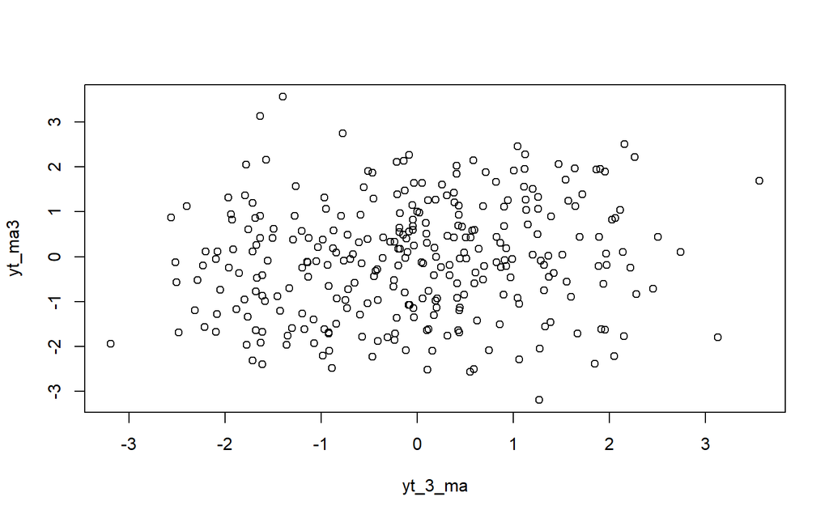

```r
plot(y=yt_ma3,x=yt_3_ma)
```

Berdasarkan scatterplot tersebut, terlihat bahwa cenderung tidak terdapat hubungan antara $Y_t$ dengan $Y_{t-2}$.

```r
cor_3 <- cor(yt_ma3,yt_3_ma)
```

Korelasi antara $Y_t$ dengan $Y_{t-3}$ hasil simulasi mendekati teori yang ada yaitu 0.1353822

### Kesimpulan

Berdasarkan scatterplot tersebut, terdapat hubungan linear positif antara $Y_t$ dengan $Y_{t-1}$ dan $Y_{t-2}$ . Namun, tidak ada hubungan antara $Y_t$ dengan $Y_{t-3}$. Begitupula dengan korelasinya yang menurun saat $Y_{t-3}$. Hal ini bersesuaian dengan Teori.

## Proses AR

Proses AR dapat dituliskan sebagai berikut:

$$y_{t} = c + e_t + \phi_{1}Y_{t-1} +
\phi_{2}Y_{t-2} + \dots + \phi_{q}Y_{t-q} = c+{e_t+\sum_{i=1}^p
\phi_iY_{t-i}}$$
Terlihat bahwa $Y_t$ berperan penting dalam pembangkitan proses AR.

## Pembangkitan Proses AR

Akan dicoba membangkitkan proses AR paling sederhana, yaitu AR(2) dengan $\phi_1 = 0.5$ dan $\phi_2 = 0.2$dan sebanyak 300 observasi dan $c=0$.

```r
set.seed(1007)
n<-length(wn)
n
```

```
## [1] 300
```

Nilai-nilai selanjutnya dapat dicari melalui *loop*. Bentuk loop dapat dilihat dari rumus AR(1) yang hendak dibangkitkan:

$$Y_t = e_t+0.5Y_{t-1}+0.2Y_{t-2}$$

```r
set.seed(1105)
n<-length(wn)
n
```

```
## [1] 300
```

```r
ar <- c(2:n)
for (i in 3:n) {ar[i]<-wn[i]+0.5*ar[i-1]+0.2*ar[i-2]}
ar
```

```
##   [1]  2.00000000  3.00000000  0.59629607  1.36575428  1.39590922  1.13570952
##   [7]  0.28279132  1.50040925  1.82335656  2.26520791  2.37882469  1.92603386
##  [13]  0.90130163 -0.72771580 -2.42441791 -2.03891642 -2.28349806 -2.76423401
##  [19] -1.01483256  0.45915055 -0.13143878  0.64966794  2.10013506  1.34229585
##  [25]  2.00424641  2.69991443  1.69154243  1.41871080  1.51068196 -1.45105252
##  [31]  0.60400821 -0.58648358 -1.06789694  1.43732902  1.06829989 -1.68754178
##  [37] -0.41485893 -0.63005856 -0.28521680 -0.69433910  0.11460675 -0.95643789
##  [43] -0.72668464 -0.84042117 -1.96768974 -2.20888318 -1.94326846 -1.37453823
##  [49]  0.54195167 -0.56167091  1.82161754  0.35596238  0.78190423  0.73165278
##  [55]  1.25634130  1.65000908 -1.34869234  0.05281962 -0.49949114  0.03783169
##  [61]  1.11090049 -0.16643084  1.74418214  1.35011369  2.12070193  1.41018017
##  [67]  2.32548506  3.13887744  0.51464665  0.26367212  1.14993103  0.60154084
##  [73]  2.10316064 -0.10711197  0.18079166  1.95401784  0.43015785 -0.52656290
##  [79] -0.29162610 -0.44875789 -1.98836830 -2.37755641 -0.69542107 -0.76181699
##  [85] -1.12549995 -1.08838605 -0.28863280  0.26352053 -0.60751761  1.28780430
```

[output cut: 35 more lines]

Selain menggunakan cara di atas, pembangkitan proses AR dapat dilakukan dengan fungsi `arima.sim()` sebagai berikut.

```r
set.seed(1105)
ar2 <- arima.sim(list(order=c(2,0,0), ar=c(0.5,0.2)), n=300)
ar2
```

```
## Time Series:
## Start = 1
## End = 300
## Frequency = 1
##   [1]  2.69789348  1.69000176  1.41753628  1.50978657 -1.45173512  0.60348783
##   [7] -0.58688029 -1.06819937  1.43709846  1.06812413 -1.68767578 -0.41496108
##  [13] -0.63013643 -0.28527617 -0.69438435  0.11457225 -0.95646420 -0.72670470
##  [19] -0.84043645 -1.96770139 -2.20889206 -1.94327524 -1.37454339  0.54194774
##  [25] -0.56167391  1.82161525  0.35596064  0.78190290  0.73165177  1.25634052
##  [31]  1.65000849 -1.34869279  0.05281928 -0.49949140  0.03783149  1.11090034
##  [37] -0.16643096  1.74418205  1.35011362  2.12070187  1.41018013  2.32548503
##  [43]  3.13887741  0.51464663  0.26367211  1.14993102  0.60154084  2.10316063
##  [49] -0.10711197  0.18079166  1.95401784  0.43015785 -0.52656290 -0.29162611
##  [55] -0.44875789 -1.98836830 -2.37755641 -0.69542107 -0.76181699 -1.12549995
##  [61] -1.08838605 -0.28863280  0.26352053 -0.60751761  1.28780430  0.90909945
```

[output cut: 39 more lines]

## Karakteristik AR(2)

### TS, ACF, dan PACF

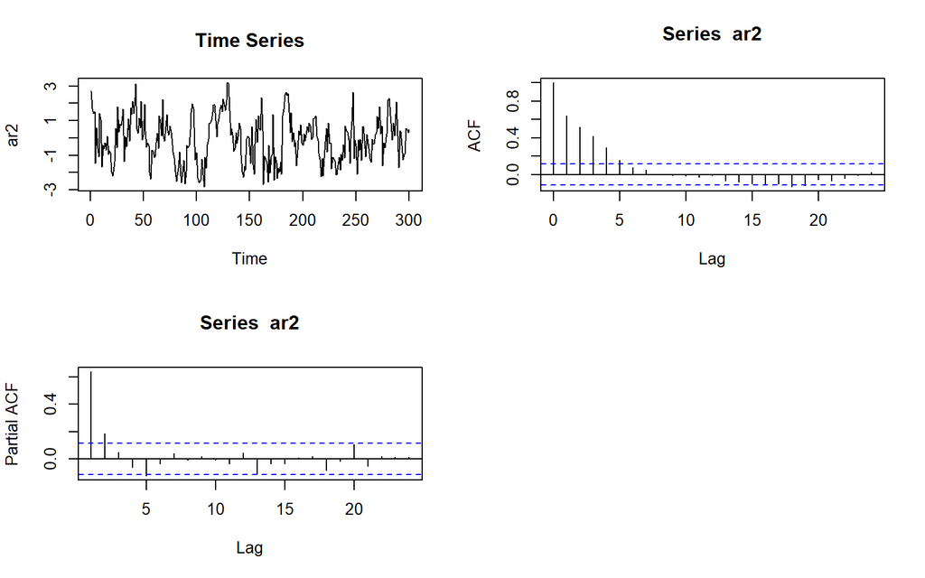

```r
par(mfrow=c(2,2))

# Plot Time Series
ts.plot(ar2)
title("Time Series")

# Plot ACF
acf(ar2)

# Plot PACF
pacf(ar2)

# Reset the plot layout
par(mfrow=c(1,1))
```

```r
TSA::eacf(ar2)
```

```
## AR/MA
##   0 1 2 3 4 5 6 7 8 9 10 11 12 13
## 0 x x x x x o o o o o o  o  o  o
## 1 x o o x o o o o o o o  o  o  o
## 2 x o o x o o o o o o o  o  o  o
## 3 x x o x o o o o o o o  o  o  o
## 4 x x x x o o o o o o o  o  o  o
## 5 x x x x x o o o o o o  o  o  o
## 6 x x o x x o o o o o o  o  o  o
## 7 x x o x o o o o o o o  o  o  o
```

Berdasarkan pola segitiga nol pada plot EACF, terlihat bahwa segitiga nol berada pada ordo AR(1) dan ordo MA(4)

### Scatterplot Antar Lag

#### Korelasi antara $Y_t$ dengan $Y_{t-1}$

```r
#Yt
yt_ar <- ar[-1]
yt_ar
```

```
##   [1]  3.00000000  0.59629607  1.36575428  1.39590922  1.13570952  0.28279132
##   [7]  1.50040925  1.82335656  2.26520791  2.37882469  1.92603386  0.90130163
##  [13] -0.72771580 -2.42441791 -2.03891642 -2.28349806 -2.76423401 -1.01483256
##  [19]  0.45915055 -0.13143878  0.64966794  2.10013506  1.34229585  2.00424641
##  [25]  2.69991443  1.69154243  1.41871080  1.51068196 -1.45105252  0.60400821
##  [31] -0.58648358 -1.06789694  1.43732902  1.06829989 -1.68754178 -0.41485893
##  [37] -0.63005856 -0.28521680 -0.69433910  0.11460675 -0.95643789 -0.72668464
##  [43] -0.84042117 -1.96768974 -2.20888318 -1.94326846 -1.37453823  0.54195167
##  [49] -0.56167091  1.82161754  0.35596238  0.78190423  0.73165278  1.25634130
##  [55]  1.65000908 -1.34869234  0.05281962 -0.49949114  0.03783169  1.11090049
##  [61] -0.16643084  1.74418214  1.35011369  2.12070193  1.41018017  2.32548506
##  [67]  3.13887744  0.51464665  0.26367212  1.14993103  0.60154084  2.10316064
##  [73] -0.10711197  0.18079166  1.95401784  0.43015785 -0.52656290 -0.29162610
##  [79] -0.44875789 -1.98836830 -2.37755641 -0.69542107 -0.76181699 -1.12549995
##  [85] -1.08838605 -0.28863280  0.26352053 -0.60751761  1.28780430  0.90909945
```

[output cut: 35 more lines]

```r
#Yt-1
yt_1_ar <- ar[-300]
yt_1_ar
```

```
##   [1]  2.00000000  3.00000000  0.59629607  1.36575428  1.39590922  1.13570952
##   [7]  0.28279132  1.50040925  1.82335656  2.26520791  2.37882469  1.92603386
##  [13]  0.90130163 -0.72771580 -2.42441791 -2.03891642 -2.28349806 -2.76423401
##  [19] -1.01483256  0.45915055 -0.13143878  0.64966794  2.10013506  1.34229585
##  [25]  2.00424641  2.69991443  1.69154243  1.41871080  1.51068196 -1.45105252
##  [31]  0.60400821 -0.58648358 -1.06789694  1.43732902  1.06829989 -1.68754178
##  [37] -0.41485893 -0.63005856 -0.28521680 -0.69433910  0.11460675 -0.95643789
##  [43] -0.72668464 -0.84042117 -1.96768974 -2.20888318 -1.94326846 -1.37453823
##  [49]  0.54195167 -0.56167091  1.82161754  0.35596238  0.78190423  0.73165278
##  [55]  1.25634130  1.65000908 -1.34869234  0.05281962 -0.49949114  0.03783169
##  [61]  1.11090049 -0.16643084  1.74418214  1.35011369  2.12070193  1.41018017
##  [67]  2.32548506  3.13887744  0.51464665  0.26367212  1.14993103  0.60154084
##  [73]  2.10316064 -0.10711197  0.18079166  1.95401784  0.43015785 -0.52656290
##  [79] -0.29162610 -0.44875789 -1.98836830 -2.37755641 -0.69542107 -0.76181699
##  [85] -1.12549995 -1.08838605 -0.28863280  0.26352053 -0.60751761  1.28780430
```

[output cut: 35 more lines]

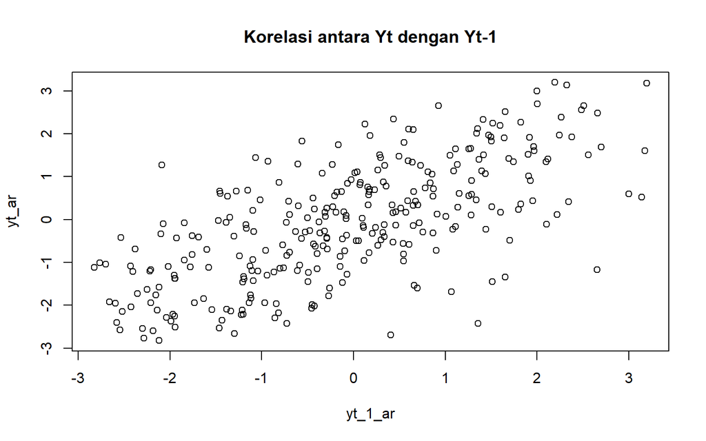

```r
plot(y=yt_ar,x=yt_1_ar, main="Korelasi antara Yt dengan Yt-1")
```

Berdasarkan scatterplot tersebut, terlihat bahwa terdapat hubungan positif antara $Y_t$ dengan $Y_{t-1}$. Hal ini sesuai dengan teori yang ada

```r
cor(yt_ar,yt_1_ar)
```

```
## [1] 0.6751436
```

Korelasi antara $Y_t$ dengan $Y_{t-1}$ dari hasil simulasi mendekati perhitungan teoritis yaitu $\rho_1=\phi^1=0.67$